# Análisis Predictivo de Precios de Acciones

Este documento presenta un análisis predictivo de los precios de varias acciones utilizando diferentes modelos de series temporales.

# Precios Normalizados de las Acciones

El primer gráfico muestra la evolución de los precios normalizados de las acciones seleccionadas durante el último año:

- **Normalización**: Los precios se han normalizado dividiendo cada valor por el precio más reciente, lo que permite comparar fácilmente el rendimiento relativo de las acciones ($\text{Precio Nomalizado}_i=\frac{\text{Precio}_i}{\text{Precio}_\text{Último}}$).
- **Tendencia**: Las líneas muestran cómo cada acción ha evolucionado en relación con su precio actual.
- **Comparación**: Podemos observar qué acciones han tenido peor rendimiento (líneas por encima de 1) o mejor rendimiento (líneas por debajo de 1) en el período analizado.

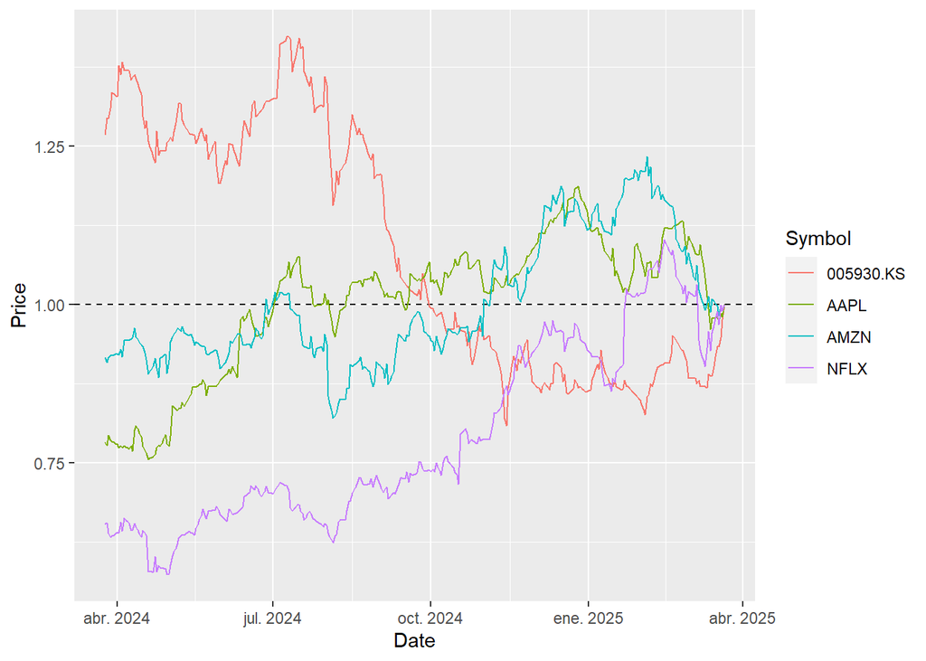

# Comparación de Modelos

Para cada acción, se generó un gráfico comparando tres modelos de predicción:

- **ARIMA**: Modelo autorregresivo integrado de media móvil, que captura tendencias y patrones en los datos.
- **Holt-Winters**: Modelo de suavizado exponencial que considera tendencia y estacionalidad.
- **NNR**: Red neuronal recurrente, un enfoque de machine learning para series temporales.

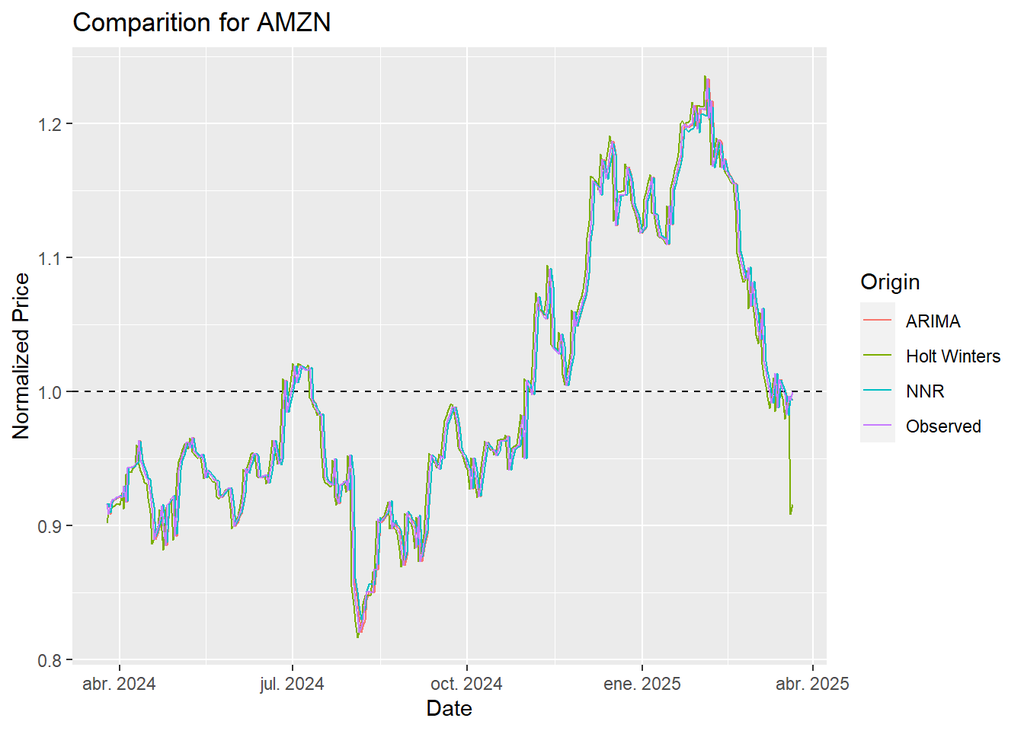

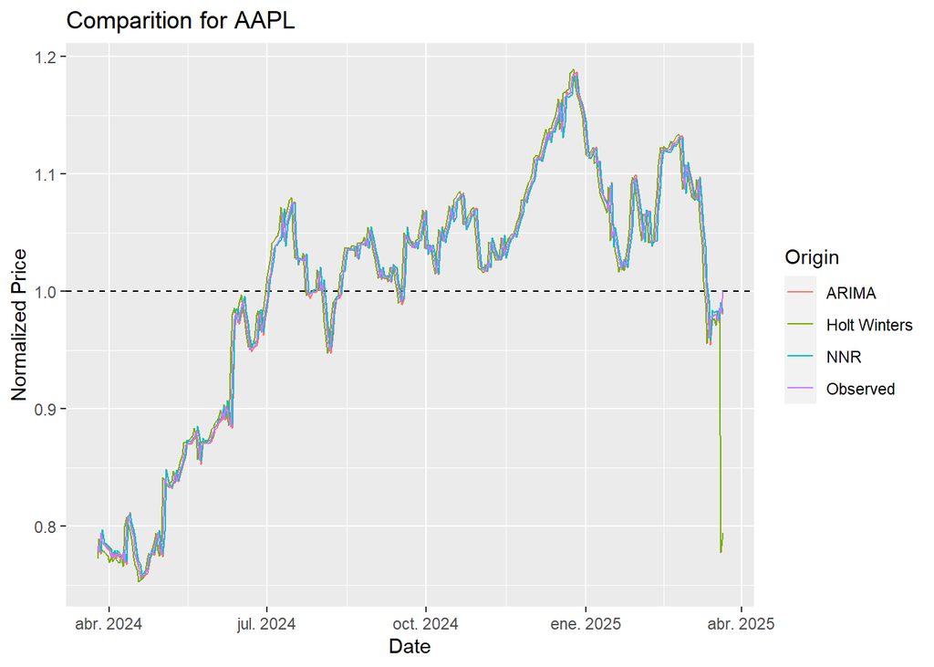

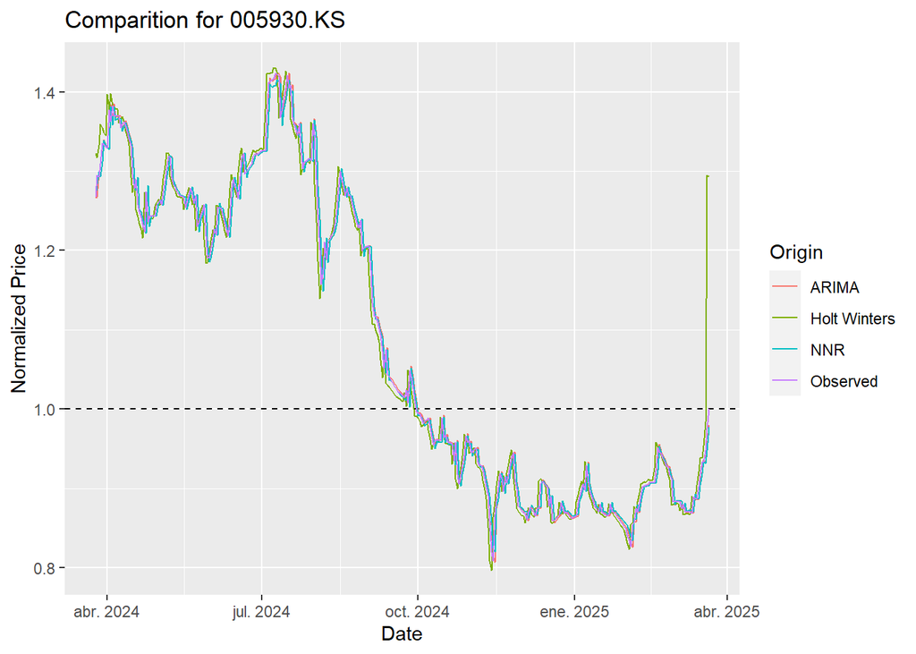

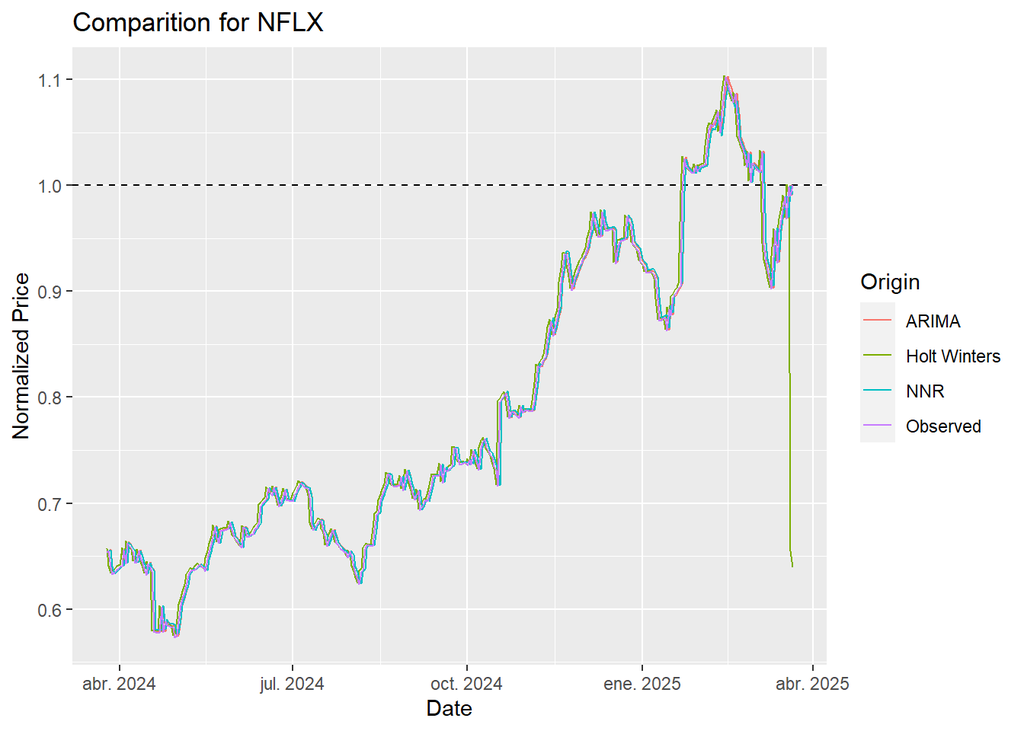

# Métrica de Evaluación: RMSE

Se utilizó el Error Cuadrático Medio Raíz (RMSE) para evaluar los modelos:

$$RMSE=\sqrt{\frac{\sum_{i=1}^n
(\text{Valor Predicho}_i-\text{Valor Observado}_i)}{n}}$$

Esta métrica mide la diferencia entre los valores predichos y observados, penalizando más los errores grandes. Para cada acción, se seleccionó el modelo con el menor RMSE.

| AMZN | NNR |
| --- | --- |
| AAPL | NNR |
| 005930.KS | NNR |
| NFLX | NNR |

# Predicción

El último gráfico combina:

- **Datos históricos** (líneas continuas)
- **Predicciones** (líneas discontinuas)

Características:

- Muestra los últimos días de datos históricos más las predicciones.
- Cada color representa una acción diferente.
- El cambio de estilo de línea (continua a discontinua) marca la transición entre datos reales y predicciones.
- Las predicciones se generaron usando el mejor modelo (según RMSE) para cada acción.

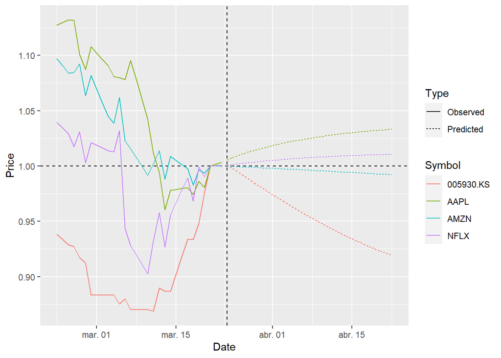

# Interpretación de Resultados

Este análisis permite:

- Comparar el rendimiento relativo de diferentes acciones.
- Evaluar qué modelo predictivo funciona mejor para cada acción.
- Obtener una proyección a corto plazo (30 días) del comportamiento de los precios.

Los inversores podrían usar esta información para:

- Identificar acciones con tendencias alcistas o bajistas.
- Tomar decisiones informadas basadas en predicciones cuantitativas.
- Comparar el rendimiento de acciones de diferentes mercados.